# (Ford Gobike Data)

## by (Mustafa Awny)

## Dataset Overview

This data set includes information about individual rides made in a bike-sharing system covering the greater San Francisco Bay area.

## (Visualization 1)

I will need to do some feature engineering and transformations to be able to visualizae the data properly.

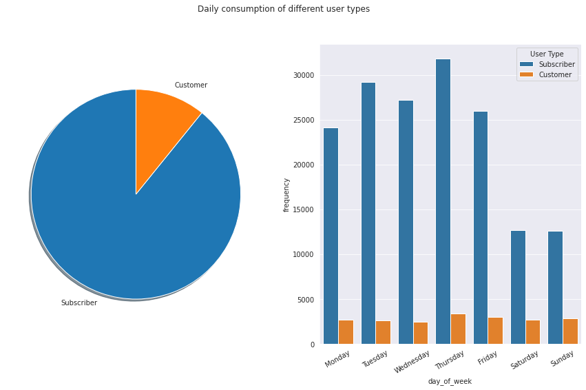

```python
plt.figure(figsize=[15, 8]);
base_color = sb.color_palette('colorblind')[0];

plt.subplot(1, 2, 1);
sorted_values = data['user_type'].value_counts()/data.shape[0];
plt.pie(sorted_values, labels=sorted_values.index, startangle=90,shadow=True);

plt.subplot(1, 2, 2);
ax = sb.countplot(data=data, x='day_of_week', hue='user_type', hue_order=sorted_values.index);
ax.legend(title='User Type');
plt.xticks(rotation=30);
plt.ylabel('frequency');
plt.suptitle('Daily consumption of different user types');
```

### We can see that the subscribers number is about 9 times the customer number. Also, we can notice that Staurday and Sunday have the lowest count of subscribers. Moreover, we can see that customers count does not depend clearly on the day of the week.

## (Visualization 2)

> You should have at least three visualizations in your presentation, but feel free to add more if you'd like!

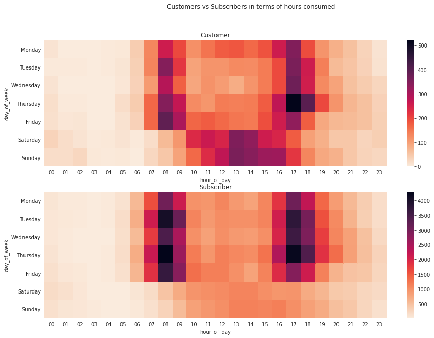

```python
plt.figure(figsize=(15, 10))
plt.suptitle('Customers vs Subscribers in terms of hours consumed')
plt.subplot(2, 1, 1)
customer = data[data['user_type'] == "Customer"]
count = customer.groupby(['day_of_week', 'hour_of_day']).size()
count = count.reset_index(name='count')
count = count.pivot(index='day_of_week', columns='hour_of_day', values='count')
sb.heatmap(count, cmap='rocket_r');
plt.title('Customer');
plt.xlabel('hour_of_day');
plt.ylabel('day_of_week');

plt.subplot(2, 1, 2)
subscriber = data[data['user_type'] == "Subscriber"]
count1 = subscriber.groupby(['day_of_week', 'hour_of_day']).size()
count1 = count1.reset_index(name='count')
count1 = count1.pivot(index='day_of_week', columns='hour_of_day', values='count')
sb.heatmap(count1, cmap='rocket_r');
plt.title('Subscriber');
plt.xlabel('hour_of_day');
plt.ylabel('day_of_week');
```

## (Visualization 3)

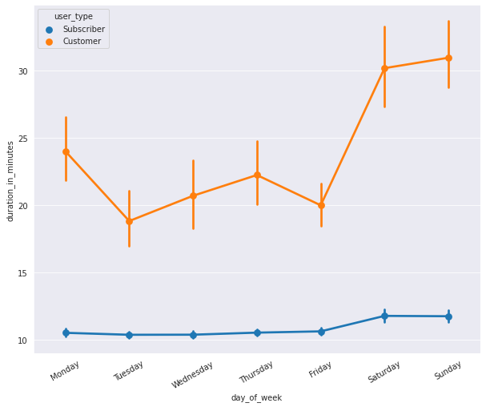

```python
plt.figure(figsize=[10, 8])
sb.pointplot(data=data, x='day_of_week', y='duration_minute', hue='user_type', hue_order=sorted_values.index);
plt.xlabel('day_of_week');
plt.ylabel('duration_in_minutes');
plt.xticks(rotation=30);
```

### We can see that Saturday and Sunday have the highest trip duration which makes sense as people tend to return back to their home places in holidays. So, thers is a seasonal trend of trip duration increase in these days.

## Conclusion

### • The number of subscribers using the bike sharing system is much more than casual customers, about 9 times.

### • Weekends have the highest trip durations for subscribers and casual customers.

### • Start and end hours of working days tend to have the highest count of both the subscribers and casual customers.

### • Subscribers tend to have less trip duration than the casual customers, which is interesting!